# Кластеризация вузов по показателям научной деятельности

Анна Бахметьева, Максим Громов, Вова Храпский

6/24/2020

## Мы сделали проект, суть такова…

В рамках проекта нами поставлена цель - выделить группы унивеситетов, близких друг к другу по отдельным показателям международной деятельности. Наиболее подходящий для этого метод, как нам показалось, неирархическая кластеризация методом К-средних.

## Несколько слов об актуальности

Законом об образовании предусмотрены специальные категории университетов - федеральные университеты и национальные исследовательские университеты (НИУ). Представляется, что НИУ должны быть близки друг к другу по результативности своей научной деятельности. Статус НИУ присваивается по результатам конкурса. При этом предполагается, что этот статус может утрачен вузом. Представляется, что на основе результатов кластерного анализа можно будет делать выводы о том, насколько справедливо те или иные получили (или наоборот - не получили) этот статус.

## Источник вдохновения

Статья А.В. Меликян «Международная образовательная деятельность российских вузов», автором которой были применены методы кластерного анализа к показателям международной деятельности университетов.

## Использованные данные

В проекте были использованы данные проводимого Минобрнауки России мониторинга эффективности деятельности образовательных организаций высшего образования за 2019 год, а именно следующие показатели научной деятельности вузов:

число публикаций, индексируемых в РИНЦ (на 100 НПР) [показатель № 2.4 в данных мониторинга], единица измерения - ед., среднее значение = 21.7, p0 = 0, p50 = 9.76, p100 = 279;

число публикаций, индексируемых в Web of Science (на 100 НПР) [2.6], единица измерения - ед., среднее значение = 306, p0 = 10.8, p50 = 270, p100 = 1080;

общий объем НИОКР [2.7], единица измерения - тыс. руб., среднее значение = 340725, p0 = 0, p50 = 60057, p100 = 8199628;

доходы от НИОКР из внебюджетных источников (на одного НПР) [2.10], единица измерения - тыс. руб., среднее значение = 253, p0 = 0, p50 = 97.8, p100 = 3186;

объем средств от НИОКР для иностранных граждан и юрлиц [3.12], единица измерения - тыс. руб., среднее значение = 4650, p0 = 0, p50 = 0, p100 = 201875.

Показатели 2.4 и 2.6 характеризуют публикационную активность вуза. Мы таже вкладываем дополнительные смыслы в показатель 2.6. Так, нами презюмируется более высокое качество публикаций для 2.6. Кроме того, 2.6, как нам кажется, косвенно характеризует вовлеченность вуза в международный научный процесс. Международный аспект научной деятельности вуза также характеризует показатель 3.12. Показатель 2.7 отражает масштаб научной деятельности вуза, а, в свою очередь, показатель 2.10 - способность вуза коммерциализировать свои исследования (но не их результаты!).

Мы оченб устали копировать данные с сайта мониторинга, поэтому выборка ограничена федеральными государственными вузами, расположенными в Центральном федеральном округе.

## Поехали!

Первым делом импортируем нужные нам библиотеки.

```r
library(tidyverse)
library (skimr)
library(factoextra)
```

А теперь - данные!

```r
data <- read.csv2("data.csv")
data_cl <- select(data, c(publ_wos, publ_rinc, overall_rnd, rnd_inc_nonbudg, rnd_inc_inostr))
scaled_data_cl <- scale(data_cl) #Данные слишком разнородны, поэтому мы сделали z-преобразование!
```

Поскольку мы даже не предполагаем, сколько кластеров может быть выделено, воспользуемся алгоритмом поиска оптимального числа кластеров.

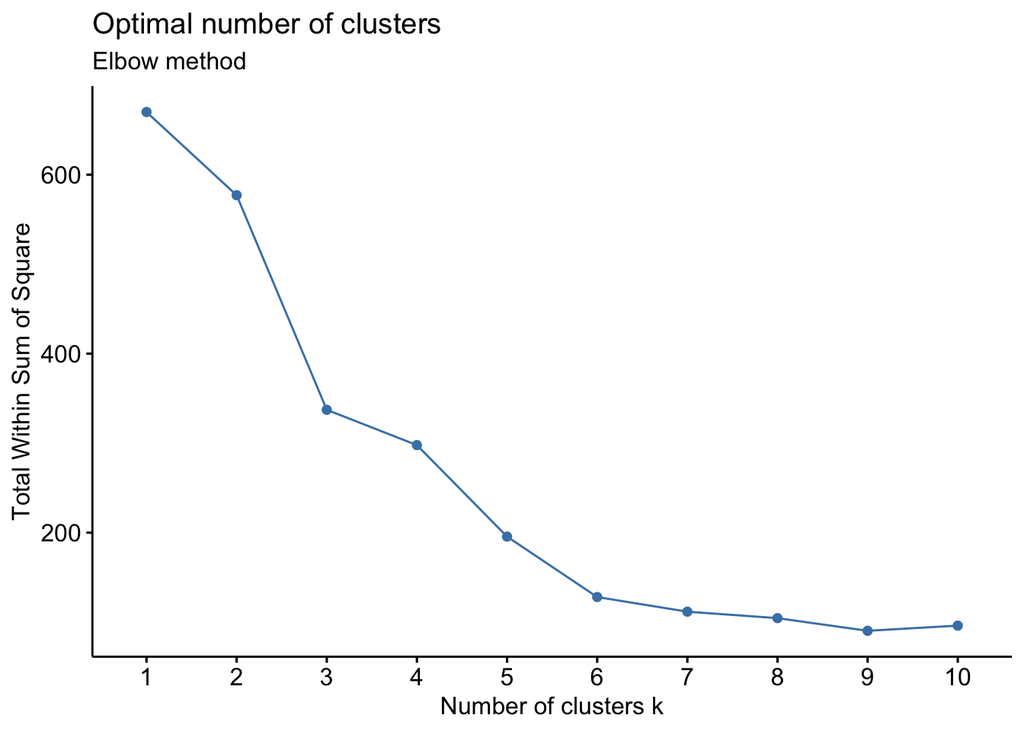

```r
fviz_nbclust(scaled_data_cl, kmeans, method = "wss")+
  labs(subtitle = "Elbow method")
```

Их 6, это точно!

А теперь, собственно, кластерный анализ методом К-средних.

```r
cl <- kmeans(scaled_data_cl, 6)
```

Соберем все в один датафрейм…

```r
df <- as.data.frame(scaled_data_cl)
df$kmeans <- cl$cluster
df$names <- data$NAME
```

И приступим к анализу!

```r
df %>% filter(kmeans == 1) %>% skim
```

Data summary

| Name | Piped data |
| --- | --- |
| Number of rows | 10 |
| Number of columns | 7 |
| _______________________ |  |
| Column type frequency: |  |
| factor | 1 |
| numeric | 6 |
| ________________________ |  |
| Group variables | None |

**Variable type: factor**

| skim_variable | n_missing | complete_rate | ordered | n_unique | top_counts |
| --- | --- | --- | --- | --- | --- |
| names | 0 | 1 | FALSE | 10 | фед: 1, Фед: 1, фед: 1, Фед: 1 |

**Variable type: numeric**

| skim_variable | n_missing | complete_rate | mean | sd | p0 | p25 | p50 | p75 | p100 | hist |
| --- | --- | --- | --- | --- | --- | --- | --- | --- | --- | --- |
| publ_wos | 0 | 1 | -0.22 | 0.22 | -0.54 | -0.42 | -0.15 | -0.10 | 0.13 | ▇▂▂▇▅ |
| publ_rinc | 0 | 1 | 2.66 | 0.52 | 1.62 | 2.47 | 2.64 | 2.72 | 3.49 | ▁▁▇▁▂ |
| overall_rnd | 0 | 1 | -0.26 | 0.13 | -0.36 | -0.33 | -0.30 | -0.27 | 0.04 | ▇▁▁▁▁ |
| rnd_inc_nonbudg | 0 | 1 | -0.32 | 0.21 | -0.55 | -0.45 | -0.38 | -0.24 | 0.16 | ▇▆▃▁▂ |
| rnd_inc_inostr | 0 | 1 | -0.21 | 0.02 | -0.21 | -0.21 | -0.21 | -0.21 | -0.16 | ▇▁▁▁▁ |
| kmeans | 0 | 1 | 1.00 | 0.00 | 1.00 | 1.00 | 1.00 | 1.00 | 1.00 | ▁▁▇▁▁ |

Кластер “РИНЦ GANG”. В данную группу попали университеты, основной результат научной деятельности котороых - обилие публикаций в журналах, индексируемых в РИНЦ. Состоит из 10 вузов - отдельных региональных (в том числе отраслевых) университетов. Сюда также угодили РЭУ им. Г.В. Плеханова и Финансовый университет.

```r
df %>% filter(kmeans == 2) %>% skim
```

Data summary

| Name | Piped data |
| --- | --- |
| Number of rows | 3 |
| Number of columns | 7 |
| _______________________ |  |
| Column type frequency: |  |
| factor | 1 |
| numeric | 6 |
| ________________________ |  |
| Group variables | None |

**Variable type: factor**

| skim_variable | n_missing | complete_rate | ordered | n_unique | top_counts |
| --- | --- | --- | --- | --- | --- |
| names | 0 | 1 | FALSE | 3 | фед: 1, Фед: 1, фед: 1, фед: 0 |

**Variable type: numeric**

| skim_variable | n_missing | complete_rate | mean | sd | p0 | p25 | p50 | p75 | p100 | hist |
| --- | --- | --- | --- | --- | --- | --- | --- | --- | --- | --- |
| publ_wos | 0 | 1 | 5.35 | 1.45 | 3.97 | 4.60 | 5.22 | 6.05 | 6.87 | ▇▁▇▁▇ |
| publ_rinc | 0 | 1 | -0.07 | 0.17 | -0.19 | -0.17 | -0.15 | -0.01 | 0.13 | ▇▁▁▁▃ |
| overall_rnd | 0 | 1 | 2.24 | 1.29 | 1.22 | 1.52 | 1.82 | 2.75 | 3.69 | ▇▇▁▁▇ |
| rnd_inc_nonbudg | 0 | 1 | 4.40 | 1.72 | 3.05 | 3.43 | 3.82 | 5.08 | 6.34 | ▇▇▁▁▇ |
| rnd_inc_inostr | 0 | 1 | 0.10 | 0.14 | -0.05 | 0.04 | 0.14 | 0.18 | 0.21 | ▇▁▁▇▇ |
| kmeans | 0 | 1 | 2.00 | 0.00 | 2.00 | 2.00 | 2.00 | 2.00 | 2.00 | ▁▁▇▁▁ |

Техно-кластер. Выдающиеся показатели по публикациям в журналах, индексируемых в Web of Science. R&D много, в том числе за внебюджетные деньги, при этом они проводятся для внутренних заказчиков. Кластер состоит из: МФТИ, МИФИ, МИСиС.

```r
df %>% filter(kmeans == 3) %>% skim
```

Data summary

| Name | Piped data |
| --- | --- |
| Number of rows | 10 |
| Number of columns | 7 |
| _______________________ |  |
| Column type frequency: |  |
| factor | 1 |
| numeric | 6 |
| ________________________ |  |
| Group variables | None |

**Variable type: factor**

| skim_variable | n_missing | complete_rate | ordered | n_unique | top_counts |
| --- | --- | --- | --- | --- | --- |
| names | 0 | 1 | FALSE | 10 | фед: 1, фед: 1, фед: 1, Фед: 1 |

**Variable type: numeric**

| skim_variable | n_missing | complete_rate | mean | sd | p0 | p25 | p50 | p75 | p100 | hist |
| --- | --- | --- | --- | --- | --- | --- | --- | --- | --- | --- |
| publ_wos | 0 | 1 | 0.64 | 0.71 | -0.46 | 0.11 | 0.61 | 1.04 | 1.84 | ▂▇▂▆▂ |
| publ_rinc | 0 | 1 | -0.34 | 0.30 | -1.07 | -0.46 | -0.23 | -0.22 | 0.01 | ▂▁▃▇▃ |
| overall_rnd | 0 | 1 | 1.09 | 0.95 | -0.23 | 0.57 | 1.00 | 1.51 | 3.16 | ▃▇▆▁▂ |
| rnd_inc_nonbudg | 0 | 1 | 1.88 | 1.28 | 0.84 | 1.01 | 1.31 | 2.53 | 4.59 | ▇▁▁▁▁ |
| rnd_inc_inostr | 0 | 1 | 0.54 | 1.17 | -0.21 | -0.15 | -0.03 | 0.59 | 3.28 | ▇▁▁▁▁ |
| kmeans | 0 | 1 | 3.00 | 0.00 | 3.00 | 3.00 | 3.00 | 3.00 | 3.00 | ▁▁▇▁▁ |

Кластер “НИУ tier”. Состоит из 10 университетов, 6 из которых имеют статус НИУ. Ориентированы на WoS-журналы, способны привлекать внебюджетные деньги на R&D, в том числе иностранные. Представляется, что 4 оставшихся могут претендовать на статус НИУ в будущем!

```r
df %>% filter(kmeans == 4) %>% skim
```

Data summary

| Name | Piped data |
| --- | --- |
| Number of rows | 2 |
| Number of columns | 7 |
| _______________________ |  |
| Column type frequency: |  |
| factor | 1 |
| numeric | 6 |
| ________________________ |  |
| Group variables | None |

**Variable type: factor**

| skim_variable | n_missing | complete_rate | ordered | n_unique | top_counts |
| --- | --- | --- | --- | --- | --- |
| names | 0 | 1 | FALSE | 2 | фед: 1, Фед: 1, фед: 0, фед: 0 |

**Variable type: numeric**

| skim_variable | n_missing | complete_rate | mean | sd | p0 | p25 | p50 | p75 | p100 | hist |
| --- | --- | --- | --- | --- | --- | --- | --- | --- | --- | --- |
| publ_wos | 0 | 1 | 1.56 | 0.18 | 1.44 | 1.50 | 1.56 | 1.63 | 1.69 | ▇▁▁▁▇ |
| publ_rinc | 0 | 1 | -0.68 | 0.08 | -0.73 | -0.71 | -0.68 | -0.65 | -0.63 | ▇▁▁▁▇ |
| overall_rnd | 0 | 1 | 5.95 | 3.36 | 3.58 | 4.77 | 5.95 | 7.14 | 8.33 | ▇▁▁▁▇ |
| rnd_inc_nonbudg | 0 | 1 | 0.83 | 0.26 | 0.64 | 0.73 | 0.83 | 0.92 | 1.01 | ▇▁▁▁▇ |
| rnd_inc_inostr | 0 | 1 | 7.32 | 2.35 | 5.66 | 6.49 | 7.32 | 8.15 | 8.98 | ▇▁▁▁▇ |
| kmeans | 0 | 1 | 4.00 | 0.00 | 4.00 | 4.00 | 4.00 | 4.00 | 4.00 | ▁▁▇▁▁ |

Кластер, состоящий из МГУ и ВШЭ. ОЧЕНЬ много R&D, в том числе для иностранцев.

```r
df %>% filter(kmeans == 5) %>% skim
```

Data summary

| Name | Piped data |
| --- | --- |
| Number of rows | 55 |
| Number of columns | 7 |
| _______________________ |  |
| Column type frequency: |  |
| factor | 1 |
| numeric | 6 |
| ________________________ |  |
| Group variables | None |

**Variable type: factor**

| skim_variable | n_missing | complete_rate | ordered | n_unique | top_counts |
| --- | --- | --- | --- | --- | --- |
| names | 0 | 1 | FALSE | 55 | фед: 1, Фед: 1, фед: 1, фед: 1 |

**Variable type: numeric**

| skim_variable | n_missing | complete_rate | mean | sd | p0 | p25 | p50 | p75 | p100 | hist |
| --- | --- | --- | --- | --- | --- | --- | --- | --- | --- | --- |
| publ_wos | 0 | 1 | -0.06 | 0.59 | -0.55 | -0.40 | -0.27 | -0.04 | 1.96 | ▇▂▁▁▁ |
| publ_rinc | 0 | 1 | 0.40 | 0.42 | -0.21 | 0.05 | 0.36 | 0.67 | 1.42 | ▇▇▆▃▂ |
| overall_rnd | 0 | 1 | -0.23 | 0.30 | -0.36 | -0.33 | -0.30 | -0.26 | 1.73 | ▇▁▁▁▁ |
| rnd_inc_nonbudg | 0 | 1 | -0.23 | 0.28 | -0.55 | -0.39 | -0.30 | -0.14 | 1.25 | ▇▃▁▁▁ |
| rnd_inc_inostr | 0 | 1 | -0.18 | 0.11 | -0.21 | -0.21 | -0.21 | -0.20 | 0.54 | ▇▁▁▁▁ |
| kmeans | 0 | 1 | 5.00 | 0.00 | 5.00 | 5.00 | 5.00 | 5.00 | 5.00 | ▁▁▇▁▁ |

Кластер “middle tier”. Выделяются только некоторым количеством РИНЦ-публикаций. Основная масса региональных университетов. Попадание в эту категорию университета, имеющего статут НИУ (2-й мед), предствляется тревожным звонком!

```r
df %>% filter(kmeans == 6) %>% skim
```

Data summary

| Name | Piped data |
| --- | --- |
| Number of rows | 55 |
| Number of columns | 7 |
| _______________________ |  |
| Column type frequency: |  |
| factor | 1 |
| numeric | 6 |
| ________________________ |  |
| Group variables | None |

**Variable type: factor**

| skim_variable | n_missing | complete_rate | ordered | n_unique | top_counts |
| --- | --- | --- | --- | --- | --- |
| names | 0 | 1 | FALSE | 55 | фед: 1, Фед: 1, фед: 1, фед: 1 |

**Variable type: numeric**

| skim_variable | n_missing | complete_rate | mean | sd | p0 | p25 | p50 | p75 | p100 | hist |
| --- | --- | --- | --- | --- | --- | --- | --- | --- | --- | --- |
| publ_wos | 0 | 1 | -0.37 | 0.23 | -0.58 | -0.53 | -0.45 | -0.29 | 0.34 | ▇▃▁▁▁ |
| publ_rinc | 0 | 1 | -0.79 | 0.32 | -1.33 | -1.08 | -0.83 | -0.59 | -0.11 | ▆▅▇▅▂ |
| overall_rnd | 0 | 1 | -0.26 | 0.16 | -0.36 | -0.35 | -0.32 | -0.26 | 0.47 | ▇▂▁▁▁ |
| rnd_inc_nonbudg | 0 | 1 | -0.33 | 0.27 | -0.55 | -0.53 | -0.42 | -0.22 | 0.77 | ▇▂▁▁▁ |
| rnd_inc_inostr | 0 | 1 | -0.16 | 0.18 | -0.21 | -0.21 | -0.21 | -0.21 | 0.70 | ▇▁▁▁▁ |
| kmeans | 0 | 1 | 6.00 | 0.00 | 6.00 | 6.00 | 6.00 | 6.00 | 6.00 | ▁▁▇▁▁ |

Кластер “Выживание”. Значительную часть кластера составляю вузы Минкультуры России, серьезной научной деятельности от которых, вероятно, никто и не ожидает (чаще всего это полное осутствие R&D и WoS-публикаций). Тем печальней такое соседство для “обычных”, в том числе технических, университетов, например, РУТ.